# HW 2 Diana Tang

Author

Diana Tang

**Libraries**

```r
library(dplyr)
library(data.table)
library(ggplot2)
library(tidytext)
library(lubridate)
library(tidyverse)
library(leaflet)
library(dtplyr)
library(ggpubr)
```

**Individual Data**

```r
if (!file.exists("chs_individual.csv"))
  download.file(
    url = "https://raw.githubusercontent.com/USCbiostats/data-science-data/master/01_chs/chs_individual.csv",
    destfile = "chs_individual.csv",
    method   = "libcurl",
    timeout  = 60
    )
chsi <- data.table::fread("chs_individual.csv")
```

**Regional Data**

```r
if (!file.exists("chs_regional.csv"))
  download.file(
    url = "https://raw.githubusercontent.com/USCbiostats/data-science-data/master/01_chs/chs_regional.csv",
    destfile = "chs_regional.csv",
    method   = "libcurl",
    timeout  = 60
    )
chsr <- data.table::fread("chs_regional.csv")
```

**Merge the data**

```r
chs <- merge(chsi, chsr, by = "townname")
chs
```

```
      townname  sid male race hispanic    agepft height weight      bmi asthma
   1:   Alpine  835    0    W        0 10.099932    143     69 15.33749      0
   2:   Alpine  838    0    O        1  9.486653    133     62 15.93183      0
   3:   Alpine  839    0    M        1 10.053388    142     86 19.38649      0
   4:   Alpine  840    0    W        0  9.965777    146     78 16.63283      0
   5:   Alpine  841    1    W        1 10.548939    150     78 15.75758      0
  ---
1196:   Upland 1867    0    M        1  9.618070    140     71 16.46568      0
1197:   Upland 2031    1    W        0  9.798768    135     83 20.70084      0
1198:   Upland 2032    1    W        0  9.549624    137     59 14.28855      0
1199:   Upland 2033    0    M        0 10.121834    130     67 18.02044      0
1200:   Upland 2053    0    W        0        NA     NA     NA       NA      0
      active_asthma father_asthma mother_asthma wheeze hayfever allergy
   1:             0             0             0      0        0       1
   2:             0             0             0      0        0       0
```

[output cut: 57 more lines]

```r
dim(chsi)
```

```
[1] 1200   23
```

```r
dim(chsr)
```

```
[1] 12 27
```

```r
dim(chs)
```

```
[1] 1200   49
```

Since we merged the 23 columns and 27 columns with the common location variable, we would expect 49 (27 + 23 = 50 - 1 = 49) columns in total as displayed above. The rows remained the same for 1200. However, there is missing data with NAs.

## Data Wrangling

**Step 1. Impute the data to replace missing values**

```r
Mode <- function(x) {
  ux <- unique(x)
  ux[which.max(tabulate(match(x, ux)))]
}
```

```r
chs <- chs %>%
  group_by(male, hispanic) %>%
  mutate(agepft = ifelse(is.na(agepft), mean(agepft, na.rm = TRUE), agepft)) %>%
  mutate(height = ifelse(is.na(height), mean(height, na.rm = TRUE), height)) %>%
  mutate(weight = ifelse(is.na(weight), mean(weight, na.rm = TRUE), weight)) %>%
  mutate(bmi = ifelse(is.na(bmi), mean(bmi, na.rm = TRUE), bmi)) %>%
  mutate(fev = ifelse(is.na(fev), mean(fev, na.rm = TRUE), fev)) %>%
  mutate(fvc = ifelse(is.na(fvc), mean(fvc, na.rm = TRUE), fvc)) %>%
  mutate(mmef = ifelse(is.na(mmef), mean(mmef, na.rm = TRUE), mmef)) %>%
  mutate(no_24hr = ifelse(is.na(no_24hr), mean(no_24hr, na.rm = TRUE), no_24hr)) %>%
  mutate(pm2_5_fr = ifelse(is.na(pm2_5_fr), mean(pm2_5_fr, na.rm = TRUE), pm2_5_fr)) %>%
  mutate(asthma = ifelse(is.na(asthma), Mode(asthma), asthma)) %>%
  mutate(active_asthma = ifelse(is.na(active_asthma), Mode(active_asthma), active_asthma)) %>%
  mutate(father_asthma = ifelse(is.na(father_asthma), Mode(father_asthma), father_asthma)) %>%
  mutate(mother_asthma = ifelse(is.na(mother_asthma), Mode(mother_asthma), mother_asthma)) %>%
  mutate(wheeze = ifelse(is.na(wheeze), Mode(wheeze), wheeze)) %>%
  mutate(hayfever = ifelse(is.na(hayfever), Mode(hayfever), hayfever)) %>%
  mutate(allergy = ifelse(is.na(allergy), Mode(allergy), allergy)) %>%
  mutate(educ_parent = ifelse(is.na(educ_parent), Mode(educ_parent), educ_parent)) %>%
  mutate(smoke = ifelse(is.na(smoke), Mode(smoke), smoke)) %>%
  mutate(pets = ifelse(is.na(pets), Mode(pets), pets)) %>%
  mutate(gasstove = ifelse(is.na(gasstove), Mode(gasstove), gasstove))
```

```r
table(is.na(chs))
```

```
FALSE
58800
```

**Step 2. Creating Obesity Level**

```r
chs$obesity_level <- ifelse(chs$bmi < 14, "Underweight BMI",
                            ifelse(chs$bmi < 22 & chs$bmi >= 14, "Normal BMI",
                                   ifelse(chs$bmi >= 22 & chs$bmi < 24, "Overweight BMI",
                                          ifelse(chs$bmi >= 24, "Obese BMI", NA))))
```

```r
chs %>%
  group_by(obesity_level) %>%
  count(obesity_level)
```

```
# A tibble: 4 × 2
# Groups:   obesity_level [4]
  obesity_level       n
  <chr>           <int>
1 Normal BMI        975
2 Obese BMI         103
3 Overweight BMI     87
4 Underweight BMI    35
```

```r
summary_obesity_levels <- chs %>%
  group_by(obesity_level) %>%
  summarize(
    min_BMI = min(bmi, na.rm = TRUE),
    max_BMI = max(bmi, na.rm = TRUE),
    total_observations = n()
  )

print(summary_obesity_levels)
```

```
# A tibble: 4 × 4
  obesity_level   min_BMI max_BMI total_observations
  <chr>             <dbl>   <dbl>              <int>
1 Normal BMI         14.0    22.0                975
2 Obese BMI          24.0    41.3                103
3 Overweight BMI     22.0    24.0                 87
4 Underweight BMI    11.3    14.0                 35
```

**Step 3. Creating Smoke Gas Exposure**

```r
chs$smoke_gas_exposure <- ifelse(chs$smoke == 0 & chs$gasstove == 0, "No Exposure",
                                 ifelse(chs$smoke == 1 & chs$gasstove == 0, "Only Smoke Exposure",
                                        ifelse(chs$smoke == 0 & chs$gasstove == 1, "Only Gas Exposure",
                                                ifelse(chs$smoke == 1 & chs$gasstove == 1,"Smoke & Gas Exposure", NA))))
```

```r
chs %>%
  group_by(smoke_gas_exposure) %>%
  count(smoke_gas_exposure)
```

```
# A tibble: 4 × 2
# Groups:   smoke_gas_exposure [4]
  smoke_gas_exposure       n
  <chr>                <int>
1 No Exposure            219
2 Only Gas Exposure      791
3 Only Smoke Exposure     36
4 Smoke & Gas Exposure   154
```

**Step 4. Four Summary Tables of Averages**

```r
summary_FEV_towns <- chs %>%
  group_by(townname) %>%
  summarize(
    mean_FEV = mean(fev, na.rm = TRUE),
    SD_FEV_Town = sd(fev, na.rm = TRUE)
  )

print(summary_FEV_towns)
```

```
# A tibble: 12 × 3
   townname      mean_FEV SD_FEV_Town
   <chr>            <dbl>       <dbl>
 1 Alpine           2087.        291.
 2 Atascadero       2076.        324.
 3 Lake Elsinore    2039.        304.
 4 Lake Gregory     2085.        320.
 5 Lancaster        2003.        317.
 6 Lompoc           2034.        351.
 7 Long Beach       1986.        319.
 8 Mira Loma        1985.        325.
 9 Riverside        1990.        278.
10 San Dimas        2027.        319.
11 Santa Maria      2026.        312.
12 Upland           2024.        343.
```

```r
summary_FEV_sex <- chs %>%
  group_by(male) %>%
  summarize(
    mean_FEV_male = mean(fev, na.rm = TRUE),
    SD_FEV_male = sd(fev, na.rm = TRUE)
  )

print(summary_FEV_sex)
```

```
# A tibble: 2 × 3
   male mean_FEV_male SD_FEV_male
  <int>         <dbl>       <dbl>
1     0         1959.        312.
2     1         2104.        308.
```

```r
summary_FEV_obesity_level <- chs %>%
  group_by(obesity_level) %>%
  summarize(
    mean_FEV_OL = mean(fev, na.rm = TRUE),
    SD_FEV_OL = sd(fev, na.rm = TRUE)
  )

print(summary_FEV_obesity_level)
```

```
# A tibble: 4 × 3
  obesity_level   mean_FEV_OL SD_FEV_OL
  <chr>                 <dbl>     <dbl>
1 Normal BMI            2000.      295.
2 Obese BMI             2266.      325.
3 Overweight BMI        2224.      317.
4 Underweight BMI       1698.      303.
```

```r
summary_FEV_smokegasexposure <- chs %>%
  group_by(smoke_gas_exposure) %>%
  summarize(
    mean_FEV_SGE = mean(fev, na.rm = TRUE),
    SD_FEV_SGE = sd(fev, na.rm = TRUE)
  )

print(summary_FEV_smokegasexposure)
```

```
# A tibble: 4 × 3
  smoke_gas_exposure   mean_FEV_SGE SD_FEV_SGE
  <chr>                       <dbl>      <dbl>
1 No Exposure                 2057.       329.
2 Only Gas Exposure           2023.       319.
3 Only Smoke Exposure         2056.       296.
4 Smoke & Gas Exposure        2025.       301.
```

## Visualization

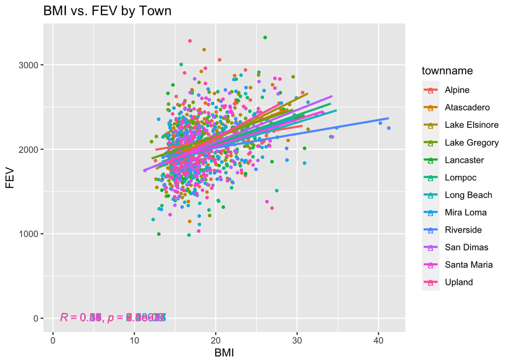

```r
ggplot(chs, aes(x = bmi, y = fev, group = townname, color = townname)) +
  geom_point (size = 1) +
  labs(
    title = "BMI vs. FEV by Town",
    x = "BMI",
    y = "FEV"
  ) + geom_smooth(method = "lm", se = FALSE) +
  stat_cor(method = "pearson", label.x = 0.85, label.y = 1)
```

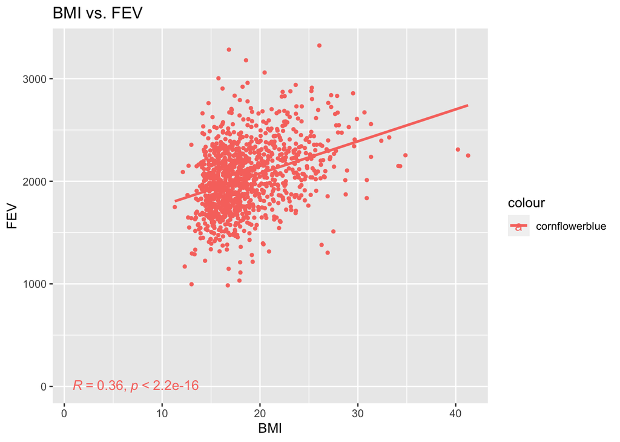

```r
ggplot(chs, aes(x = bmi, y = fev, color = "cornflowerblue")) +
  geom_point (size = 1) +
  labs(
    title = "BMI vs. FEV",
    x = "BMI",
    y = "FEV"
  ) + geom_smooth(method = "lm", se = FALSE) +
  stat_cor(method = "pearson", label.x = 0.85, label.y = 1)
```

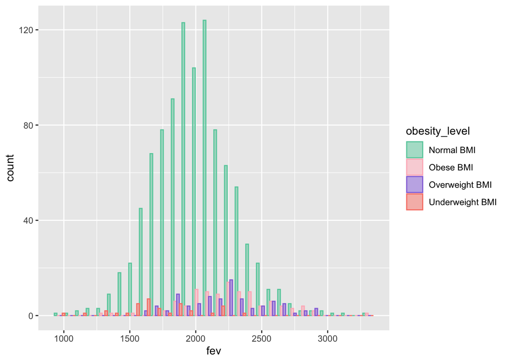

```r
custom_colors <- c("mediumaquamarine", "lightpink", "mediumpurple", "salmon")

chs %>%
  ggplot(aes(x = fev, fill = obesity_level, color = obesity_level)) +
  geom_histogram(alpha = 0.5, position = "dodge") +
  scale_fill_manual(values = custom_colors) +
  scale_color_manual(values = custom_colors)
```

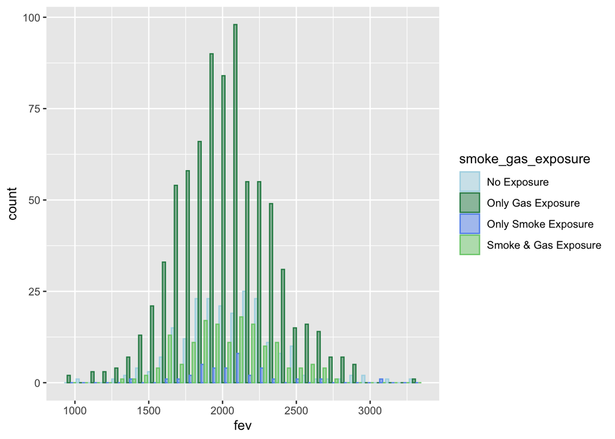

```r
custom_colors2 <- c("lightblue", "seagreen", "cornflowerblue", "palegreen3")

chs %>%
  ggplot(aes(x = fev, fill = smoke_gas_exposure, color = smoke_gas_exposure)) +
  geom_histogram(alpha = 0.5, position = "dodge") +
  scale_fill_manual(values = custom_colors2) +
  scale_color_manual(values = custom_colors2)
```

**Step 3. Barchart of BMI by smoke/gas exposure**

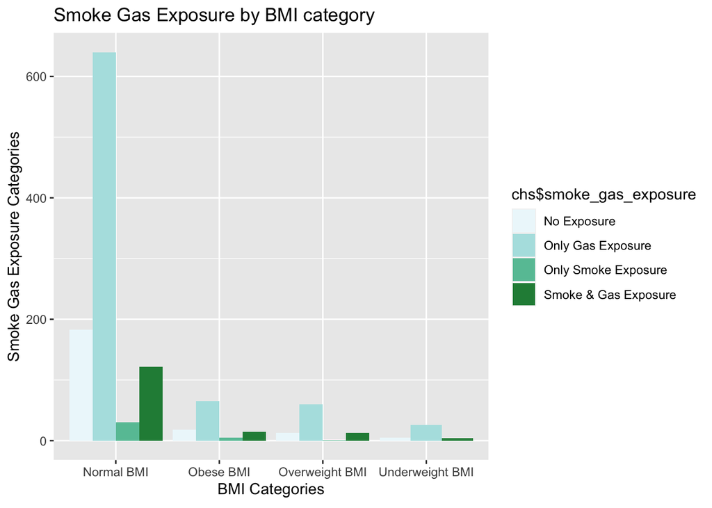

```r
chs %>%
  ggplot() +
  geom_bar(mapping = aes(x = chs$obesity_level, fill = chs$smoke_gas_exposure), position = "dodge") +
  scale_fill_brewer(palette = 2) +
  labs(title = "Smoke Gas Exposure by BMI category") +
  labs(x = expression("BMI Categories"), y = "Smoke Gas Exposure Categories")
```

**Step 4. Statistical Summary Graphs of FEV by BMI and FEV by smoke/gas exposure category**

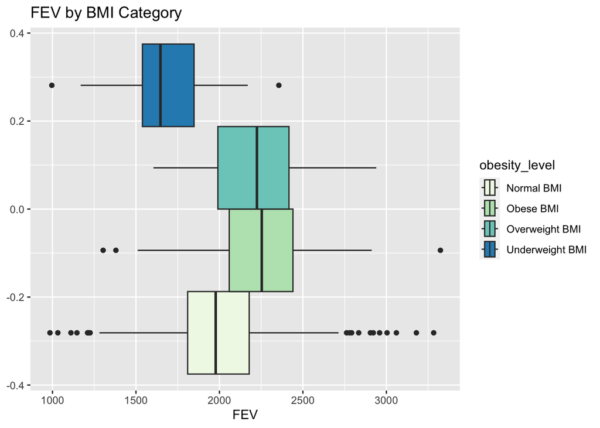

```r
chs %>%
  ggplot() +
  geom_boxplot(mapping = aes(x = fev, fill = obesity_level), position = "dodge") +
  scale_fill_brewer(palette = 4) +
  labs(title = "FEV by BMI Category") +
  labs(x = expression("FEV"))
```

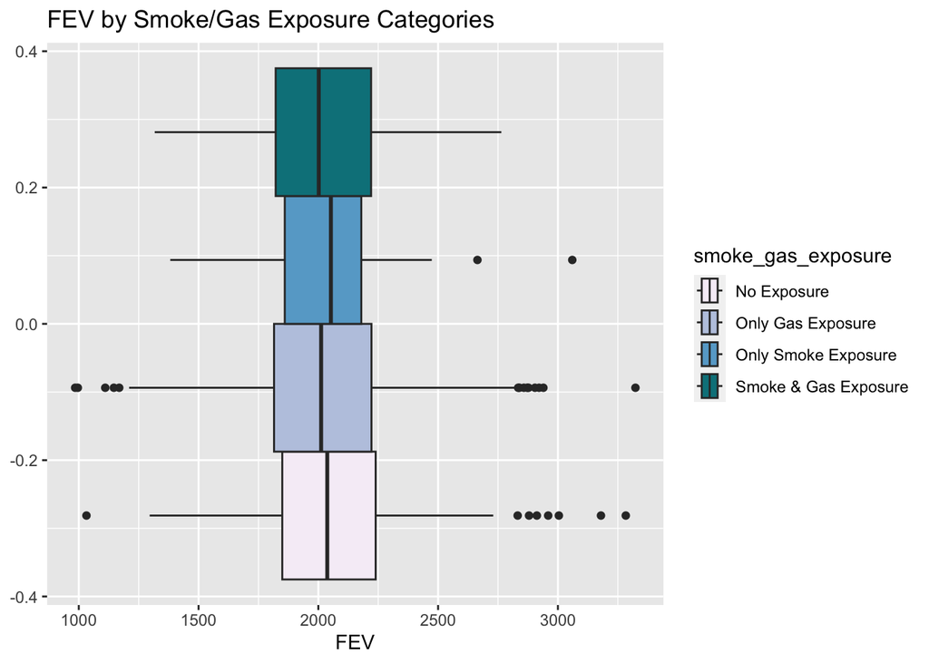

```r
chs %>%
  ggplot() +
  geom_boxplot(mapping = aes(x = fev, fill = smoke_gas_exposure), position = "dodge") +
  scale_fill_brewer(palette = 10) +
  labs(title = "FEV by Smoke/Gas Exposure Categories") +
  labs(x = expression("FEV"))
```

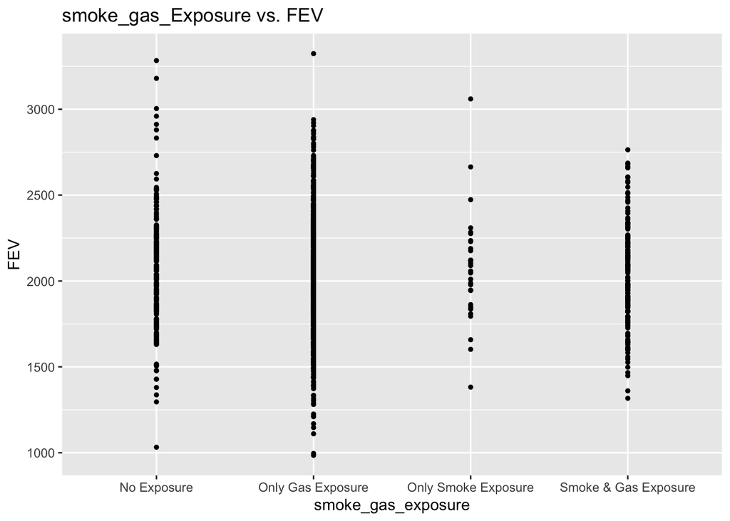

```r
ggplot(chs, aes(x = smoke_gas_exposure, y = fev, group = smoke_gas_exposure)) +
  geom_point (size = 1) +
  labs(
    title = "smoke_gas_Exposure vs. FEV",
    x = "smoke_gas_exposure",
    y = "FEV"
  ) + geom_smooth(method = "lm", se = FALSE) +
  stat_cor(method = "pearson", label.x = 0.85, label.y = 1)
```

**Step 5. A leaflet map showing the concentrations of PM2.5 mass in each of the CHS communities.**

```r
PM25.pal <- colorNumeric(c('lightpink','mediumpurple','mediumaquamarine', 'salmon', 'lightblue', 'cornflowerblue'), domain=chs$pm25_mass)
PM25.pal
```

[output not shown]

```r
PM25map <- leaflet(chs) %>%
  # The looks of the Map
  addProviderTiles('CartoDB.Positron') %>%
  # Some circles
  addCircles(
    lat = ~lat, lng=~lon,
                                                  # HERE IS OUR PAL!
    label = ~paste0(round(pm25_mass,2), ' C'), color = ~ PM25.pal(pm25_mass),
    opacity = 1, fillOpacity = 1, radius = 500
    ) %>%
  # Add text
  addLabelOnlyMarkers(
    lat = ~lat, lng = ~lon, label = ~paste0(round(pm25_mass, 2), ' Concentration'),
    labelOptions = labelOptions(noHide = TRUE, direction = 'right')
  ) %>%
  # And a pretty legend
  addLegend('bottomleft', pal=PM25.pal, values=chs$pm25_mass,
          title='PM2.5 mass', opacity=1)
PM25map
```

[interactive chart not shown]

**Step 6. Choose a visualization to examine whether PM2.5 mass is associated with FEV.**

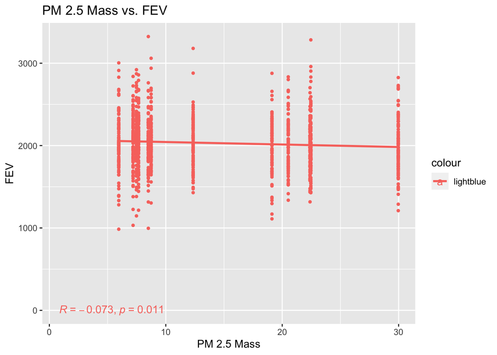

```r
ggplot(chs, aes(x = pm25_mass , y = fev, color = 'lightblue')) +
  geom_point (size = 1) +
  labs(
    title = "PM 2.5 Mass vs. FEV",
    x = "PM 2.5 Mass",
    y = "FEV"
  ) + geom_smooth(method = "lm", se = FALSE) +
  stat_cor(method = "pearson", label.x = 0.85, label.y = 1)
```

## Looking at the Data (EDA)

Following the EDA checklist we used these initial questions to outline the data wrangling and visualization part of our assignment. We imported the data, merged it properly, and checked doing so by looking at the dimensions, imputing the values to replace the NAs, and finally checking to see if the NAs were appropriately removed. Data transformations included categorizing certain data columns further for visualization and analysis. Our summary plots included box plots and correlation graphs with appropriate correlation values. We made specific visualization plots to then answer these questions.

**Step 1. What is the association between BMI and FEV?** The association between BMI and FEV appears to be positively correlated, albeit weakly. When shown and grouped by town, we can see the positive correlation of higher BMI being associated with higher FEV. When just looking at BMI vs FEV we can see that the correlation coefficient is R = 0.36, showing that it is a weak positive correlation.

**Step 2. What is the association between smoke + gas exposure and FEV?** As for smoke + gas exposure and FEV, from the box plots in our statistical summary graphs there appear to not be a correlation or strong association between the different subgroups. From looking at the box plots, each boxplot of FEV seems to overlap between each of the subgroups with similar medians.

**Step 3. What is the association between PM2.5 exposure and FEV?** After visualizing the PM2.5 Exposure vs. FEV as a scatterplot and looking at the correlation coefficient, we can see that the data does not appear to have a strong correlation. If anything, we may even say that there is no correlation given that the R value of -0.073 is so close to 0, indicating no correlation at all.